# Working Report_Black Friday

```r
summary(rules2) # 25 rules
```

```
## set of 25 rules
##
## rule length distribution (lhs + rhs):sizes
##  1
## 25
##
##    Min. 1st Qu.  Median    Mean 3rd Qu.    Max.
##       1       1       1       1       1       1
##
## summary of quality measures:
##     support         confidence          lift       count
##  Min.   :0.2001   Min.   :0.2001   Min.   :1   Min.   :1179
##  1st Qu.:0.2084   1st Qu.:0.2084   1st Qu.:1   1st Qu.:1228
##  Median :0.2284   Median :0.2284   Median :1   Median :1346
##  Mean   :0.2302   Mean   :0.2302   Mean   :1   Mean   :1356
##  3rd Qu.:0.2405   3rd Qu.:0.2405   3rd Qu.:1   3rd Qu.:1417
##  Max.   :0.3153   Max.   :0.3153   Max.   :1   Max.   :1858
##
## mining info:
##   data ntransactions support confidence
##  items          5892     0.2       0.05
```

There are now 25 association rules - cool! This will be way more manageable for us to understand and visualize. We can use the RColorBrewer to look nice visualizations of our rule set.

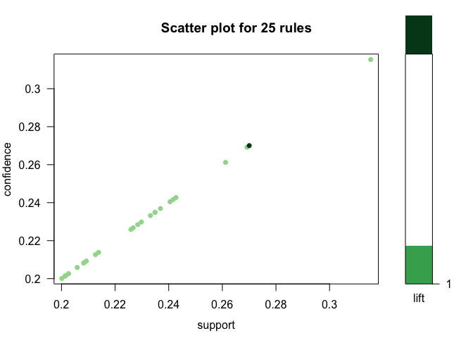

```r
library(RColorBrewer)
plot(rules2,
     control=list(jitter=0, col = rev(brewer.pal(9, "Greens")[4:9])),
     shading = "lift")
```

Let’s look at the top rules by support to confirm our insights.

```r
inspect(head(sort(rules2, by = "support")))
```

```
##     lhs    rhs         support   confidence lift count
## [1] {}  => {P00265242} 0.3153428 0.3153428  1    1858
## [2] {}  => {P00110742} 0.2700272 0.2700272  1    1591
## [3] {}  => {P00025442} 0.2691785 0.2691785  1    1586
## [4] {}  => {P00112142} 0.2612016 0.2612016  1    1539
## [5] {}  => {P00057642} 0.2427020 0.2427020  1    1430
## [6] {}  => {P00184942} 0.2416836 0.2416836  1    1424
```

As suspected, the rules with the highest support level do not have any lhs variables listed. Let’s see if we can fix this by adjusting the confidence parameter upwards to .75 and the support parameter downwards to .01. We specify the maxtime parameter as zero to let the model run as long as needed. (rules can take a while to model with a low support parameter)

```r
rules3 <- apriori(data = items,
                  parameter = list(support = 0.01, confidence = 0.75, maxtime = 0))
```

```
## Apriori
##
## Parameter specification:
##  confidence minval smax arem  aval originalSupport maxtime support minlen
##        0.75    0.1    1 none FALSE            TRUE       0    0.01      1
##  maxlen target   ext
##      10  rules FALSE
##
## Algorithmic control:
##  filter tree heap memopt load sort verbose
##     0.1 TRUE TRUE  FALSE TRUE    2    TRUE
##
## Absolute minimum support count: 58
##
## set item appearances ...[0 item(s)] done [0.00s].
## set transactions ...[10539 item(s), 5892 transaction(s)] done [0.18s].
## sorting and recoding items ... [1958 item(s)] done [0.01s].
## creating transaction tree ... done [0.00s].
## checking subsets of size 1 2 3 4 5 done [8.60s].
## writing ... [5 rule(s)] done [0.24s].
## creating S4 object  ... done [0.19s].
```

Boom - only 5 rules are left after we increase the confidence and lower the support. Let’s visualize these again using the same techniques as before.

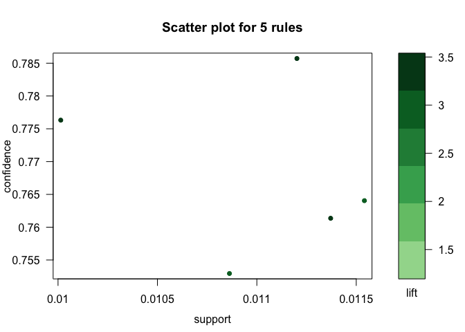

```r
plot(rules3,
     control=list(jitter=0, col = rev(brewer.pal(9, "Greens")[4:9])),
     shading = "lift")
```

Great - no direct relationship between support and confidence. Let’s double check the underlying data to be sure.

```r
inspect(head(sort(rules3, by = "support")))
```

```
##     lhs                                rhs         support    confidence
## [1] {P00057642,P00105142,P00127342} => {P00025442} 0.01154107 0.7640449
## [2] {P00070042,P00117942,P00277642} => {P00145042} 0.01137135 0.7613636
## [3] {P00003242,P00111142,P00127842} => {P00145042} 0.01120163 0.7857143
## [4] {P00057942,P00105142,P00182242} => {P00110742} 0.01086219 0.7529412
## [5] {P00128942,P00144642,P00329542} => {P00057642} 0.01001358 0.7763158
##     lift     count
## [1] 2.838432 68
## [2] 3.241297 67
## [3] 3.344963 66
## [4] 2.788391 64
## [5] 3.198638 59
```

Awesome - products are showing up in the lhs and rhs columns so we know that there are real association rules being used here. Now, it is time to plot the rules.

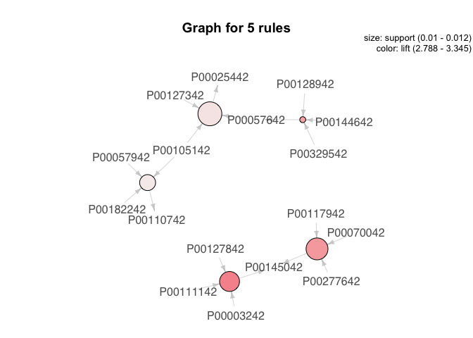

```r
plot(rules3, method = 'graph')
```

And there you have it - our association rules have been visualized. We can see which products correspond to each rule based on the arrows pointing from each product ID to the circles representing each rule. The two rules shown in the top left are colored lighter for their relatively low lift values, and the rule shown in the top right is tiny due to its relatively low support value.

It would be far more interesting if we could understand which products these codes represent. Without that information, we cannot fully understand the findings of our analysis or create actionable recommendations on it.